# Exercise 7 - Natural Selection

Mahdi Robbani

March 8, 2020

# Natural selection (and other complications)

**Hans R. Siegismund**

### Exercise 1

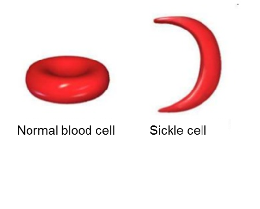

In Africa and southern Europe, many human populations are polymorphic at the locus coding for the beta-hemoglobin chain. Two alleles are found, Hb<sup>S</sup>, and Hb<sup>A</sup>. Hb<sup>S</sup> differs from HbA in that it at the position 6 the amino acid glutamic acid has been replaced with valine. A study in Tanzania found the following genotypic distribution:

|  | Hb<sup>A</sup>Hb<sup>A</sup> | Hb<sup>A</sup>Hb<sup>S</sup> | Hb<sup>S</sup>Hb<sup>S</sup> | Sum |
| --- | --- | --- | --- | --- |
| Adults | 400 | 249 | 5 | 654 |
| Children | 189 | 89 | 9 | 287 |

1. **Estimate the allele frequencies in both groups.**
2. **Do the observed genotype distributions differ from Hardy-Weinberg proportions?**

**Answer:**

| Adults | Hb<sup>A</sup>Hb<sup>A</sup> | Hb<sup>A</sup>Hb<sup>S</sup> | Hb<sup>S</sup>Hb<sup>S</sup> | Sum |
| --- | --- | --- | --- | --- |
| Observed | 400 | 249 | 5 | 654 |
| Expected | 420.64 | 207.71 | 25.64 | 654 |

where

*p*(A) = 0.802

*p*(S) = 0.198

The test for Hardy-Weinberg proportions gives χ<sup>2</sup> = 25.84, which is highly significant. We see that this is caused by a large excess of heterozygotes.

| Children | Hb<sup>A</sup>Hb<sup>A</sup> | Hb<sup>A</sup>Hb<sup>S</sup> | Hb<sup>S</sup>Hb<sup>S</sup> | Sum |
| --- | --- | --- | --- | --- |
| Observed | 189 | 89 | 9 | 287 |
| Expected | 189.97 | 87.05 | 9.97 | 287 |

where

*p*(A) = 0.814

*p*(S) = 0.186

In this case the test for Hardy-Weinberg proportions is χ<sup>2</sup> = 0.14, which is non-significant. We also see that the allele frequencies among children and adults are similar. We do not bother to make a formal test for it.

As might be known, the low survival of the Hb<sup>S</sup>Hb<sup>S</sup> genotype is due to sickle cell anemia. They have a high probability of dying because of this. The Hb<sup>A</sup>Hb<sup>S</sup> heterozygote is compared to the Hb<sup>A</sup>Hb<sup>A</sup> homozygote more resistant to malaria. We therefore have a system of overdominance.

3. **Under the assumption that the polymorphism has reached a stable equilibrium, estimate the fitness of the three genotypes. Hints: Assume that the adults had a genotypic distribution equal to their expected Hardy-Weinberg distribution and estimate their relative fitness.**

**Answer:**

| Adults | Hb<sup>A</sup>Hb<sup>A</sup> | Hb<sup>A</sup>Hb<sup>S</sup> | Hb<sup>S</sup>Hb<sup>S</sup> | Sum |
| --- | --- | --- | --- | --- |
| Observed | 400 | 249 | 5 | 654 |
| Expected | 420.64 | 207.71 | 25.64 | 654 |
| Fitness (O/E) | 0.951 | 1.199 | 0.195 |  |
| Relative fitness | 0.793 | 1.000 | 0.163 |  |
| Selection coefficient | 0.207 | 0 | 0.837 |  |

We can see that the selection against the HbSHbS genotype is very severe. We can use the selection coefficient to estimate the equilibrium allele frequency

*p* = *t*/(*s* + *t*) = 0.837/(0.207 + 0.837) = 0.802

This value is identical to the estimated allele frequency among the adults. The reason is that we have estimated it under the assumption of equilibrium.

In African Americans, one out of 400 suffers of sickle cell anemia.

4. **Estimate the allele frequencies among them**

**Answer:**

*q* = √(1/400) = 0.05

5. **Why is it lower than the frequency observed among Africans?**

**Answer:**

There is no longer malaria in the USA. It has been eliminated. Therefore, there is no longer overdominant selection that keeps a high allele frequency of the deleterious allele. There has been directional selection against the deleterious allele, which has reduced its frequency.

### Exercise 2

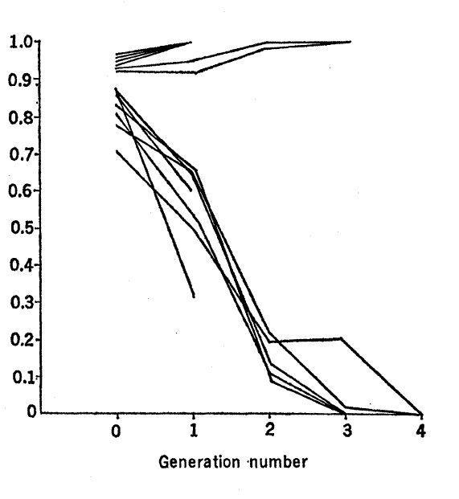

The figure to the right shows the result of 13 repeated experiments with a chromosomal polymorphism in *Drosophila meanogaster*. It shows the frequency of one of the two chromosomal forms through four generations the experiment lasted. In six of the experiments one type had frequencies slightly higher than 0.9 and 7 of the experiments had levels below 0.9. Population sizes in each experiment were 100.

1. **Can the evolution of this system be explained as a result of genetic drift?**

**Answer:**

No. It is highly unlikely that genetic drift in a population with a size of 100 can result in fixation after 4 generations. In addition, all six experiments starting with a frequency of about 0.9 end up being fixed for one allele, while the seven experiments, which start with a rate is below 0.9 all end up being fixed for the other allele. Genetic drift would have a more “random” nature.

2. **Can the evolution be explained as a result of natural selection? How does it work? Which genotype has the lowest fitness?**

**Answer:**

Yes; there must be underdominance where the heterozygote has a lower fitness than both homozygotes.

### Exercise 3

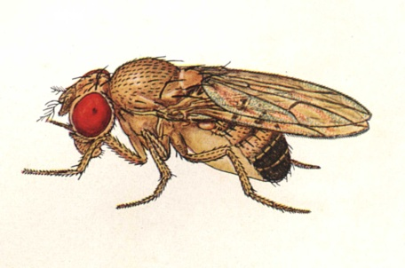

A geneticist starts an experiment with *Drosophila melanogaster*. He uses 10 populations, each kept at a constant size of 8 males and 8 females in each generation. In generation 0 all individuals are heterozygous for the two alleles *A*<sub>1</sub> and *A*<sub>2</sub> at an autosomal locus. After 19 generations, the following distribution of the allele frequency of *A*<sub>1</sub> is observed in the 10 populations:

| 0.18 | 0.00 | 0.18 | 0.25 | 0.30 | 0.19 | 0.16 | 0.00 | 0.15 | 0.00 |
| --- | --- | --- | --- | --- | --- | --- | --- | --- | --- |

1. **Can this distribution of the allele frequency be explained by genetic drift?**

** Answer: **

No. With genetic drift, the allele frequencies would be distributed randomly over the entire range from 0 to 1. Here, all 10 populations have an allele frequency of less than 0.5, which is very unlikely. (0.5<sup>10</sup> = 0.000977)

2. **Which other evolutionary force has also worked during this experiment?**

**Answer:**

Natural selection.

*After 100 generations, all ten populations were fixed for allele A*<sub>2</sub>*.*

3. **Use this information to explain how the fitness of the three genotypes, *w*<sub>11</sub>, *w*<sub>12</sub> and *w*<sub>22,</sub> are related to each other.**

**Answer:**

Natural selection has also been involved, in this case in the form of directional selection, where

*w*<sub>11</sub> < *w*<sub>12</sub> < *w*<sub>22,</sub>

### Exercise 4

[figure not shown]

After the arrival of the Europeans in America, the California condor (*Gymnogyps californianus*) was severely hunted. This resulted in a drastic decline in population size, which culminated in 1987 when the last wild condors were placed in captivity (fourteen individuals). [Later on, the condor was released again. In 2014, 425 were living in the wild or in captivity.] Among the progeny of these fourteen individuals the genetic disease chondrodystrophy (a form of dwarfism was observed). In condor, this disease is inherited at an autosomal locus where chondrodystrophy is due to a recessive lethal allele.

1. **What has the frequency of the allele for chondrodystrophy at least been among the fourteen individuals who were used to found the population in captivity?**

**Answer:**

*q* ≥ 2/(2 x 14) = 0.071

There must at least have been two heterozygotes among the fourteen individuals.

*The population has since grown in number and reached around a few hundred. An estimation of the allele frequency for chondrodystrophy showed a value of 0.09.*

2. **Can the frequency of this lethal allele be caused by one of the following three forces separately? (In question c you will be asked whether a combination of these forces is needed to explain the frequency.)**
- mutation
- genetic drift
- natural selection

**Answer:**

- mutation: No
- genetic drift: Yes
- natural selection: No
3. **Is it necessary to consider that two or three of these forces act together to explain the frequency of this allele?**

**Answer:**

The allele for chondrodystophy arose through mutation and genetic drift has resulted in the high frequency. (Natural selection eliminates this allele, and thus would not be able to explain the high frequency of allele.)

4. **What is the expected frequency of the allele after a balance between mutation and selection? The mutation rate can be assumed to be μ = 10<sup>-6</sup>?**

**Answer:**

The equilibrium between mutation and natural selection is given by

*p* = √(μ/*s*) = √(10<sup>-6</sup> /1) = 0.001.

### Exercise 5

Cystic fibrosis is caused by a recessive allele at a single autosomal locus, CTFR (cystic fibrosis transmembrane conductance regulator). In European populations 1 out of 2500 newborn children are homozygous for the recessive allele.

1. **What is the frequency of the recessive allele in these populations?**

**Answer:**

*q* = √ (1/2500) = 1/50 = 0.02

2. **What fraction of all possible parental combinations has a probability of ¼ for having a child which is homozygous for the recessive allele?**

**Answer:**

It must be the combination heterozygote × heterozygote:

2*pq* × 2*pq* (2 × 0.98 × 0.02)<sup>2</sup> = 0.0392<sup>2</sup> = 0.0015

*The disease used to be fatal during childhood if it is not treated. Therefore, it must be assumed that the fitness of the recessive homozygote must have been 0 during the main part of the human evolutionary history.*

3. **Estimate the mutation rate, assuming equilibrium between the mutation and selection.**

**Answer:**

*q =* √*(μ/s*),

where *μ* in is the mutation rate and *s* is the selection coefficient, which must be 1 since the fitness is 0.

Therefore,

*μ* = *q*<sup>2</sup>*s* = 0.02<sup>2</sup> × 1 = 0.0004

*A direct estimate of the mutation rate was 6.7 × 10<sup>-7</sup>, which is considerably lower than the estimate found in question c.*

4. **Which mechanism(s) may explain the high frequency of the recessive deleterious allele?**

**Answer:**

It could be overdominant selection where the fitness of heterozygous carriers is higher than in homozygous normal. There have been several hypotheses for this: increased resistance against tuberculosis or cholera has been suggested but there are no hard data to explain it.